# Assignment 3

The US Department of Agriculture publishes price estimates for fruits and vegetables [online](https://www.ers.usda.gov/data-products/fruit-and-vegetable-prices/fruit-and-vegetable-prices/). The most recent estimates are based on a 2013 survey of US retail stores.

The estimates are provided as a collection of MS Excel files, with one file per fruit or vegetable. The `assignment3_data.zip` file contains the fruit and vegetable files in the directories `fruit` and `vegetables`, respectively.

**Exercise 1.1.** Use pandas to extract the "Fresh" row(s) from the **fruit** Excel files. Combine the data into a single data frame. Your data frame should look something like this:

| type | food | form | price_per_lb | yield | lb_per_cup | price_per_cup |
| --- | --- | --- | --- | --- | --- | --- |
| fruit | watermelon | Fresh1 | 0.333412 | 0.52 | 0.330693 | 0.212033 |
| fruit | cantaloupe | Fresh1 | 0.535874 | 0.51 | 0.374786 | 0.3938 |
| vegetables | onions | Fresh1 | 1.03811 | 0.9 | 0.35274 | 0.406868 |
| ... |  |  |  |  |  |  |

It's okay if the rows and columns of your data frame are in a different order. These modules are especially relevant:

- [`str` methods](https://docs.python.org/2/library/stdtypes.html#string-methods)
- [`os`](https://docs.python.org/2/library/os.html)
- [`os.path`](https://docs.python.org/2/library/os.path.html)
- [pandas](http://pandas.pydata.org/pandas-docs/stable/): `read_excel()`, `concat()`, `.fillna()`, `.str`, plotting methods

Ask questions and search the documentation/web to find the functions you need.

```python
import pandas as pd
import numpy as np
import os
import math
import matplotlib
import matplotlib.pyplot as plt
matplotlib.style.use("ggplot")
```

```python
def readFood(folder):
    """
    Input: Name of the folder to read the excel files from
    Output: A dataframe with information for each fruit (one per file). Each
    fruit is a row and there are seven columns.
    """
    # Read each file and save in fileContent:
    files = [x for x in os.listdir(folder) if not x.startswith("~")] # Get all file names
    os.chdir(folder) # Enter the folder with those files
    fileContent = [pd.read_excel(fname, sep = '\t') for fname in files] # Read each file and save in a list

    os.chdir("..") # Move back out to the directory we started in for future reads

    # Pull out the fresh row from each dataframe and modify it to the format we want
    count = 0
    for fc in fileContent:

        # Eliminate unnecessary columns that some files have and rename columns:
        if fc.shape[1] > 7:
            for j in xrange(7, fc.shape[1]):
                fc = fc.drop('Unnamed: ' + str(j), 1)
        fc.columns = ['form', 'price_per_lb', 'type', 'yield', 'lb_per_cup', 'food', 'price_per_cup']

        # Some files have many types of that produce, so we want to catch those:
        problem = False
        if fc.loc[2, "price_per_lb"] == " ":
            problem = True
        elif math.isnan(fc.loc[2, "price_per_lb"]):
            problem = True

        # Insert appropriate values for type and food:
        fc.loc[2, "type"] = folder
        fc.loc[2, "food"] = files[count].split(".")[0]

        # Drop all but the second row, drop the second row if not Fresh, and drop problem produce
        fc = fc.drop( xrange(3, fc.shape[0]))
        if fc.loc[2, "form"].find("Fresh") == -1:
            fc = fc.drop([2])
        elif problem == True:
            fc = fc.drop([2])
        fc = fc.drop([0, 1])
        fileContent[count] = fc
        count += 1

    # Combine into one DataFrame:
    together = pd.concat(fileContent)

    return together

fruitDF = readFood("fruit")
fruitDF.head()
```

|  | form | price_per_lb | type | yield | lb_per_cup | food | price_per_cup |
| --- | --- | --- | --- | --- | --- | --- | --- |
| 2 | Fresh1 | 1.56752 | fruit | 0.9 | 0.242508 | apples | 0.422373 |
| 2 | Fresh1 | 3.04007 | fruit | 0.93 | 0.363763 | apricots | 1.1891 |
| 2 | Fresh1 | 0.566983 | fruit | 0.64 | 0.330693 | bananas | 0.292965 |
| 2 | Fresh1 | 5.77471 | fruit | 0.96 | 0.31967 | blackberries | 1.92292 |
| 2 | Fresh1 | 4.73462 | fruit | 0.95 | 0.31967 | blueberries | 1.59318 |

```python
fruitDF.index.values
```

```
array([2, 2, 2, 2, 2, 2, 2, 2, 2, 2, 2, 2, 2, 2, 2, 2, 2, 2, 2, 2, 2, 2, 2,
       2], dtype=int64)
```

**Exercise 1.2.** Reuse your code from exercise 1.1 to extract the "Fresh" row(s) from the **vegetable** Excel files.

Does your code produce the correct prices for tomatoes? If not, why not? Do any other files have the same problem as the tomatoes file?

You don't need to extract the prices for these problem files. However, make sure the prices are extracted for files like asparagus that don't have this problem.

```python
veggieDF = readFood("vegetables")
veggieDF.head()
```

|  | form | price_per_lb | type | yield | lb_per_cup | food | price_per_cup |
| --- | --- | --- | --- | --- | --- | --- | --- |
| 2 | Fresh1 | 1.17225 | vegetables | 0.458554 | 0.451948 | acorn_squash | 1.15536 |
| 2 | Fresh1 | 2.21305 | vegetables | 0.375309 | 0.385809 | artichoke | 2.27497 |
| 2 | Fresh1 | 3.21349 | vegetables | 0.493835 | 0.396832 | asparagus | 2.58227 |
| 2 | Fresh1 | 2.23587 | vegetables | 0.740753 | 0.31967 | avocados | 0.964886 |
| 2 | Fresh1 | 2.76355 | vegetables | 1.06 | 0.341717 | brussels_sprouts | 0.890898 |

My original code had NaNs in the price position for tomatoes and a few other vegetables. This was because the files for those vegetables had many types within the vegetable, and prices for each. So, tomatoes has grape and cherry, roma, and beefsteak. This means that there are no overall values for tomato price, yield, and so on. Just values for within each type. (It was easier for me to adjust my 1.1 function to handle this instead of in 1.3, so the printed head of the data frame does not show this problem I talk about).

**Exercise 1.3.** Remove rows without a price from the vegetable data frame and then combine the fruit and vegetable data frames. Make sure all columns of numbers are numeric (not strings).

Note: I removed the rows without a price in my 1.1 function.

```python
produce = pd.concat([fruitDF, veggieDF])
print produce.shape
produce.head()
```

```
(47, 7)
```

|  | form | price_per_lb | type | yield | lb_per_cup | food | price_per_cup |
| --- | --- | --- | --- | --- | --- | --- | --- |
| 2 | Fresh1 | 1.56752 | fruit | 0.9 | 0.242508 | apples | 0.422373 |
| 2 | Fresh1 | 3.04007 | fruit | 0.93 | 0.363763 | apricots | 1.1891 |
| 2 | Fresh1 | 0.566983 | fruit | 0.64 | 0.330693 | bananas | 0.292965 |
| 2 | Fresh1 | 5.77471 | fruit | 0.96 | 0.31967 | blackberries | 1.92292 |
| 2 | Fresh1 | 4.73462 | fruit | 0.95 | 0.31967 | blueberries | 1.59318 |

**Exercise 1.4.** Discuss the questions below (a paragraph each is sufficient). Use plots to support your ideas.

#### 1. What kinds of fruits are the most expensive (per pound)? What kinds are the least expensive?

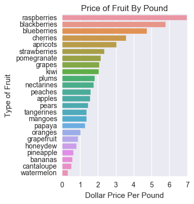

```python
import seaborn as sns
max10 = fruitDF.sort_values(by = "price_per_lb", ascending = False)
ax = sns.factorplot(y = "food", x = "price_per_lb", data = max10, kind = "bar", orient = "h")
ax.set(xlabel = "Dollar Price Per Pound", ylabel = "Type of Fruit")
plt.title("Price of Fruit By Pound")
plt.show()
```

```python
import seaborn as sns
max10 = fruitDF.sort_values(by = "price_per_lb", ascending = False)
ax = sns.factorplot(y = max10.index, x = "price_per_lb", data = max10, kind = "bar", orient = "h")
ax.set(xlabel = "Dollar Price Per Pound", ylabel = "Type of Fruit")
plt.title("Price of Fruit By Pound")
plt.show()
```

[output not shown]

[output cut: 11 more lines]

[output not shown]

To answer this I made the plot above. It shows a sorted bar plot with the price per pound of each fruit. The most expensive fruit is at the top of plot. It is raspberries, and it is followed by blackberries and blueberries. The least expensive fruit is at the bottom. It is watermelon and the two fruits above it are cantaloupe and then banana.

#### 2. How do the price distributions compare for fruit and vegetables?

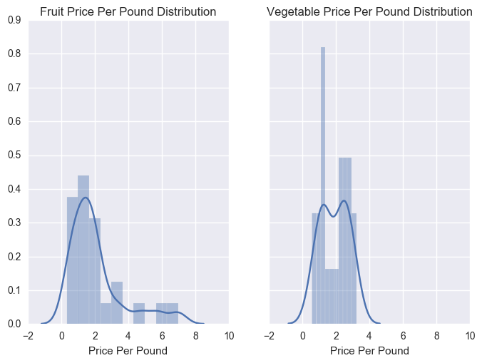

```python
fig, (ax1, ax2) = plt.subplots(ncols=2, nrows = 1, sharey = True, sharex = True)
sns.distplot(fruitDF.loc[:, "price_per_lb"], ax = ax1, bins = 10, axlabel = "Price Per Pound")
ax1.set_title("Fruit Price Per Pound Distribution")
sns.distplot(veggieDF.loc[:, "price_per_lb"], ax = ax2, bins = 10, axlabel = "Price Per Pound")
ax2.set_title("Vegetable Price Per Pound Distribution")
plt.show()
```

To answer this question, I plotted histograms for each distribution side by side above. The fruit distribution is skewed right and has most of its prices between zero and four. The vegetable distribution is symmetric with most of its prices between one and three.

#### 3. Which foods are the best value for the price?

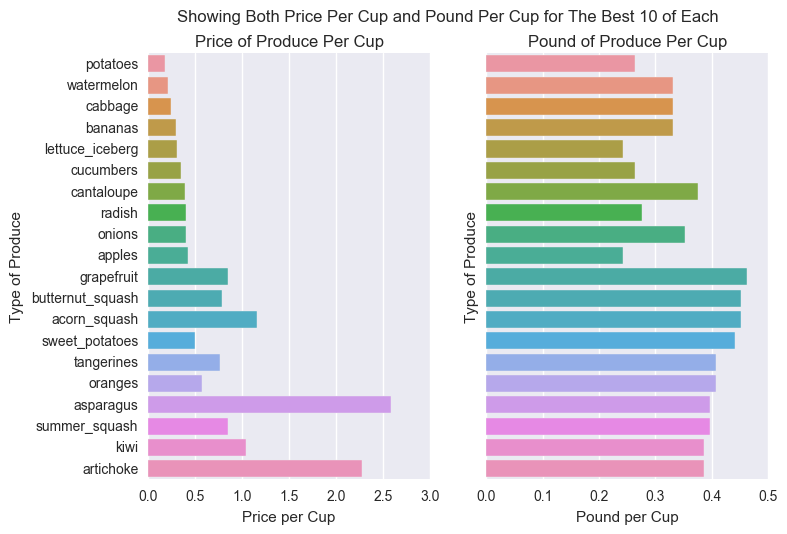

[figure not shown]

[figure not shown]

```python
leastPrice10 = produce.sort_values(by = "price_per_cup").head(10)
mostCup10 = produce.sort_values(by = "lb_per_cup", ascending = False).head(10)
combine = pd.concat([leastPrice10, mostCup10])
fig, (ax1, ax2) = plt.subplots(ncols=2, nrows = 1, sharey = True)
plt.suptitle('Showing Both Price Per Cup and Pound Per Cup for The Best 10 of Each')
sns.factorplot(y = "food", x = "price_per_cup", data = combine, ax = ax1, kind = "bar", orient = "h")
sns.factorplot(y = "food", x = "lb_per_cup", data = combine, ax = ax2, kind = "bar", orient = "h")
ax1.set(xlabel = "Price per Cup", ylabel = "Type of Produce")
ax2.set(xlabel = "Pound per Cup", ylabel = "Type of Produce")
ax1.set_title("Price of Produce Per Cup")
ax2.set_title("Pound of Produce Per Cup")
plt.show()
```

To answer this question, I grabbed the 10 foods with the smallest price per cup and the 10 foods with the highest pound per cup and then joined them together. I then plotted the price per cup and pound per cup side by side for each food in that joined data frame. So, to find the foods with the best value for price, we want to find the smallest bar on the left and the largest bar on the right, or the food with the best to offer on both sides. Some of the best ones are cantaloupe, sweet potatoes, and onions.

#### 4. What's something surprising about this data set?

```python
ax5 = fruitDF.plot(kind = "scatter", x = "yield", y = "price_per_lb", label = "Fruit", color = "Blue")
ax5 = veggieDF.plot(kind = "scatter", x = "yield", y = "price_per_lb", ax = ax5, label = "Vegetable", color = "Green")
ax5.legend()
plt.title("Yield Versus Price Per Pound for Fresh Produce")
ax5.set(ylabel = "Price Per Pound (Dollars)", xlabel = "Preparation Yield Factor")
plt.show()
```

[output not shown]

[output not shown]